# HW3

聖心女子大学国際交流学科 2026年秋学期

アジア経済研究所 伊藤成朗

# はじめに

図の表示

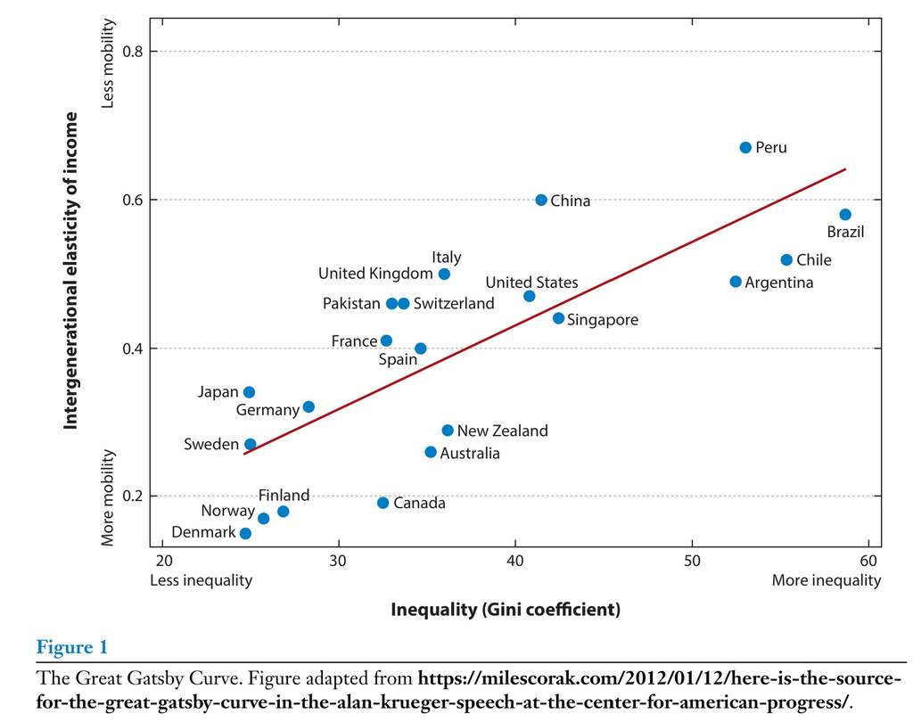

Durlauf, Kourtellos, and Tan (2022)

出所: [このページ](https://www.annualreviews.org/content/journals/10.1146/annurev-economics-082321-122703)にpdfがあります

リスト

長所

- 歪みなく効果を計測できる(internal validity)
  1. (結果に疑問を挟む余地は少ないので無駄な議論を節約できる)
  2. 被験者をランダムに治療群the treatedと統御群the cotrolに割り振り、前者にのみ介入
  3. Randomisation of treatment: 治療群と統御群は相似、異なるのは介入の有無だけ
  4. 結果指標の違いは介入が原因と解釈可能
- それ以外にない
- 一気に
- 表示させる

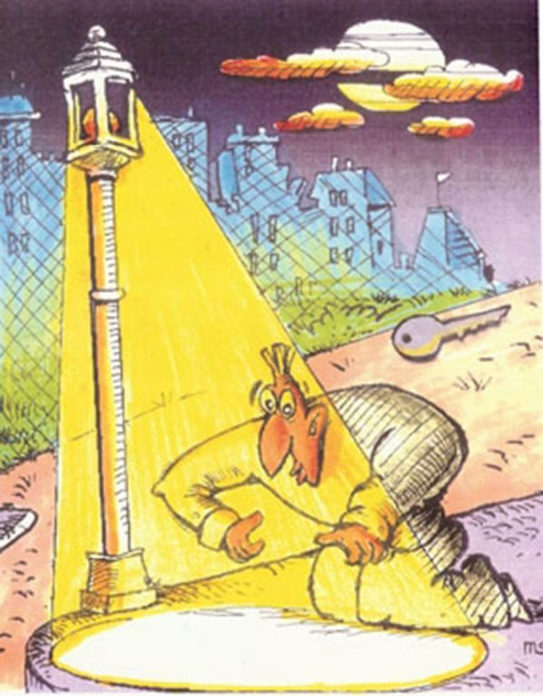

鍵を捜す男

出所: https://diabetes.diabetesjournals.org/content/64/4/1105

**ATT**

Average treatment effects on the treated: 実施群における平均効果

$$ATT = E[y_{1i}|D_{i}=1]-E[y_{0i}|D_{i}=1].$$

2列表示

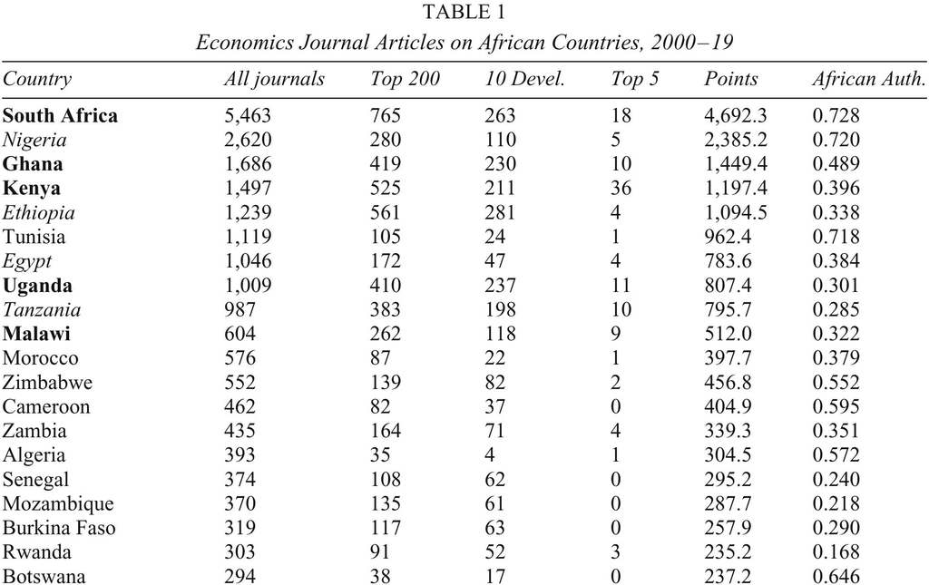

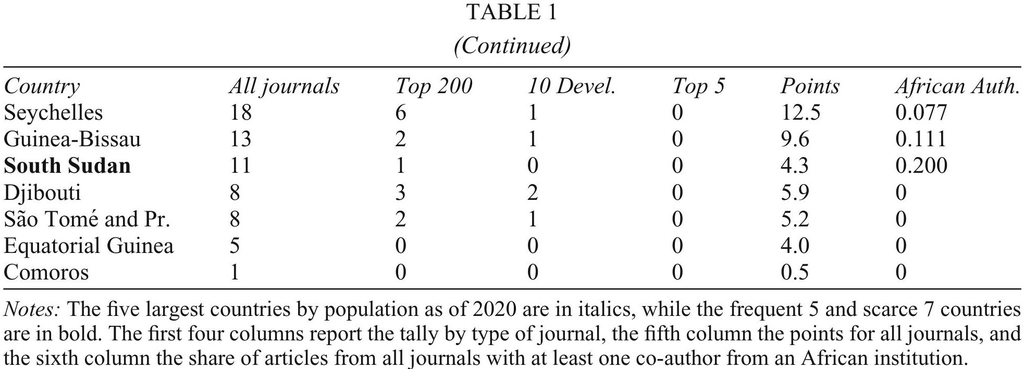

Porteous (2022), Table 1

- 人口が多い英語公用語国がトップ
- 自国で学術雑誌を持っていると上位(e.g., South African Journal of Economics)

アフリカの経済研究で得られた知識=こうした地域からの知識

知識の出自が偏っていることを知るべき

1. 西アフリカでも同じ結果?
2. アフリカ中央部でも同じ結果?

自国での研究がないと、効果が異なる(かもしれない)のに政策が実施されてしまうかも、という意味で不利

- 文字が大きい
- 色を弱めずに反転

```powershell
& 'C:\seiro\languages\R\R-4.4.1\bin\Rscript.exe' -e "rmarkdown::render('HW3_rmarkdown.rmd')"
```

https://pkg.yihui.org/rmarkdown-book/slidy-presentation

# References

Durlauf, Steven N., Andros Kourtellos, and Chih Ming Tan. 2022. “The Great Gatsby Curve.” Journal Article. *Annual Review of Economics* 14 (Volume 14, 2022): 571–605. https://doi.org/10.1146/annurev-economics-082321-122703.

Porteous, Obie. 2022. “Research Deserts and Oasis: Evidence from 27 Thousand Economics Journal Articles on Africa.” *Oxford Bulletin of Economics and Statistics* 84 (6): 1235–58. https://doi.org/10.1111/obes.12510.